# ROSALIND 10-14 Tips

COMP 383/483

2023-02-07 13:53:17

### Class [ROSALIND](http://rosalind.info/classes/969/) page.

#### Problem 10 GBK (1 pt)

- See the **Programming Shortcut**. Use the `Bio.Entrez` and `Bio.SeqIO` modules. Entrez requires your email address, a precaution against excessive usage. See the [Biopython tutorial](http://biopython.org/DIST/docs/tutorial/Tutorial.html#htoc110) for details. You can always try your search on the [NCBI Nucleotide database](https://www.ncbi.nlm.nih.gov/nucleotide) to figure out how to structure your query.
- Additional **Sample Data** for testing/debugging
- [Input](https://hwheeler01.github.io/CompBio/rosalind_gbk.txt)
- [Output](https://hwheeler01.github.io/CompBio/out_gbk.txt)

#### Problem 11 GRPH (2 pts)

- Consider storing FASTA IDs as keys and sequences as values in a dictionary. Then, you can use the `itertools.combinations` method from the `itertools` module. For example:

```python
import itertools
#combinations method from itertools module pulls all pairwise (2) keys from dict
for k1,k2 in itertools.combinations(datadict, 2):
  #k1 is one key from datadict
  #k2 is another key from datadict
  #do something with them
```

- Additional **Sample Data** for testing/debugging
- [Input](https://hwheeler01.github.io/CompBio/rosalind_grph.txt)
- [Output](https://hwheeler01.github.io/CompBio/out_grph.txt)

#### Problem 12 DBRU (2 pts)

- Understand how sets work in Python (review Problem 7), use your reverse complement function (or Biopython’s method) from previous problems, and it should be fairly straightforward to print the adjacency list.
- Additional **Sample Data** for testing/debugging
- [Input](https://hwheeler01.github.io/CompBio/rosalind_dbru.txt)
- [Output](https://hwheeler01.github.io/CompBio/out_dbru.txt)

#### Problem 13 LONG (2.5 pts)

- One of the two most challenging ROSALIND problems.
- Builds on number 11 GRPH. (Review “Assembly_Algorithms.pptx” on Week03 [Sakai](https://sakai.luc.edu/) for inspiration.)
- The greedy shortest common superstring algorithm will return the correct answer given constraints of this problem.
- Thus, start by finding the two strings with the longest overlap, replace these two strings with their merged string, then search for the next longest overlap, and repeat until you only have one merged string.
- Consider writing functions to find the overlap between two strings and the pair of strings with the maximum overlap in a list of strings.
- Additional **Sample Data** for testing/debugging
- [Input](https://hwheeler01.github.io/CompBio/rosalind_long.txt)
- [Output](https://hwheeler01.github.io/CompBio/out_long.txt)

#### Problem 14 GASM (2.5 pts)

- The other most challenging ROSALIND problem.
- Builds on number 12 DBRU. (Review “Assembly_Algorithms.pptx” on Week03 on [Sakai](https://sakai.luc.edu/) for inspiration.)
- You don’t know which value of `k` gives exactly two directed cycles, so iterate until you find the right value of `k`.
- For each value of `k` starting with the read length, build the `k-1` de Bruijn graph and try to build just 2 directed cycles that consume all of your edges. For example, here are the k=5 and k=4 graphs of the small [Sample Dataset](http://rosalind.info/problems/gasm/?class=969). For this sample case, k=5 has no cycles and k=4 gives exactly 2 directed cycles.
- **k=5**

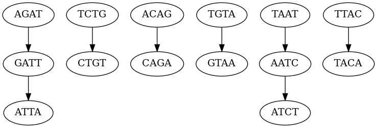

  __________________________________________________________________
- **k=4**

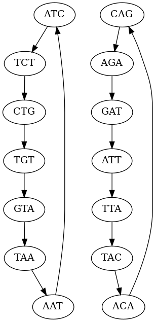

- Remember, when the suffix of one edge matches the prefix of a second edge, you simply add the last character of the second edge’s suffix to the growing superstring.
- Keep in mind your superstrings may be a rotation of the Sample Dataset output, since they are cyclic.
- Also, the problem asks for one cyclic superstring, so you shouldn’t write both that you find.
- Additional **Sample Data** for testing/debugging
- [Input](https://hwheeler01.github.io/CompBio/rosalind_gasm.txt)
- [Output](https://hwheeler01.github.io/CompBio/out_gasm.txt)

#### Visualizing graphs with [graphviz](https://graphviz.readthedocs.io/en/stable/manual.html)

- You may find it helpful to visualize graphs as you develop your solutions to Problems 11-14.
- Install the [graphviz software](https://www.graphviz.org/download/) first. Then install the `graphviz` module: `pip install graphviz` or `pip3 install graphviz` should work. (Or use the class servers, graphviz is installed on both.)
- Here’s how to visualize the de Bruijn graph from the [Sample Output](http://rosalind.info/problems/dbru/?class=969) from Problem 12 DBRU:

```python
import graphviz
dbg = graphviz.Digraph('dBgraph', format='png')
with open("sample_output_12.txt", 'r') as f:
    for line in f:
        e1, e2 = line.rstrip().split(', ')
        e1 = e1[1:]
        e2 = e2[:-1]
        dbg.edge(e1, e2)
dbg.render()
```

- The above code will write a `dBgraph.gv.png` file that looks like this:

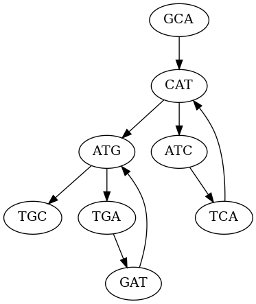

*On the due date, in class, you may be asked questions about how your code works and your comments will help you explain. Inability to explain how your code works will result in a reduced grade.*